# R Workshop – Day 2

Yun Wang / Franziska Metge

# Outline

1. Loops (solution to yesterday’s homework)
2. Write your own function
3. Installing R packages (cran and bioconductor)
4. Basic plotting functions

# Yesterday’s Homework

1. Load the table generated in ‘create_gene_expression_table.R’ using `source()`
2. Return all genes which are significant differentially expressed
3. Use the `t.test()$p.value` and a for loop
4. Groups are as following:
- Group 1: Rep 1-4
- Group 2: Rep 5-8

```r
source('data/create_gene_expression_table.R')
head(Experiment_DEG)
```

```
##   gene_id      Rep1      Rep2      Rep3      Rep4      Rep5      Rep6      Rep7
## 1  gene_1 105.39212  94.43991 116.86898 141.04485  93.34523 115.71146 113.25906
## 2  gene_2  87.40029 142.94498  51.73186  94.68184  70.89883 115.54474 102.72603
## 3  gene_3 117.37320  79.42240 121.76722  79.98960 108.93147 112.08996  76.63101
## 4  gene_4 134.54391  77.28999 126.44761  91.36372  78.83684 104.22875 105.84413
## 5  gene_5 100.48375 143.68578 105.27493 104.19477 116.44813  86.16445 107.04300
## 6  gene_6 107.36050 118.16668 108.50700  84.17187 109.03643 103.13020 111.16444
##        Rep8
## 1  82.68450
## 2 104.11582
## 3  87.15789
## 4 115.79650
## 5 110.42031
## 6  69.55446
```

```r
# number of rows
nrow(Experiment_DEG)
```

```
## [1] 10000
```

```r
# Calculate the t.test for each gene using a for loop
for(i in 1:nrow(Experiment_DEG)){
  ttest = t.test(Experiment_DEG[i, 2:5], Experiment_DEG[i, 6:9])
  Experiment_DEG[i, 'pvals'] = as.numeric(ttest$p.value)
}

sig_genes = subset(Experiment_DEG, pvals < 0.05)
head(sig_genes)
```

```
##    gene_id      Rep1      Rep2      Rep3      Rep4      Rep5      Rep6
## 9   gene_9 100.89746  97.88367  81.36704  72.10379 125.20080 102.89918
## 18 gene_18  78.11254 128.89679 104.40530  80.52714 288.22143 339.39495
## 28 gene_28 147.08409 107.19818  97.33347 110.56184  45.02459  29.03283
## 31 gene_31  86.57081  91.29552  93.72615  94.03866 111.41650 114.84582
## 44 gene_44  96.59012 119.89421 123.82437 122.51155  92.48579  88.68119
## 54 gene_54 125.26516 103.57519 133.01888  78.57679 240.08713 159.04118
##         Rep7      Rep8       pvals
## 9  101.75088 129.53450 0.036647331
## 18 207.08595 368.39356 0.007092463
## 28  37.18410  34.28281 0.003420114
## 31 120.94572  93.94537 0.042010774
## 44  87.94522  99.71087 0.027705550
## 54 299.95045 294.92011 0.018264558
```

```r
nrow(sig_genes)
```

```
## [1] 1424
```

# Write your own function

When to write a function:

- if you repeat the same procedure with minor changes or on different data

How is the basic structure of a function

```r
myFunctionName <- function(arg1, arg2, ...){
  <Do something with arg1 and arg2...>
  return(result)
}
```

There are two main principles how to write a function

- Think first and design the function as you go along (more experianced programmers)
- Wrap a function around already written code

## Easy examples

You want a function that calculates the square of a given number

```r
Square <- function(x){

  result = x * x

  return(result)
}

Square(3)
```

```
## [1] 9
```

No we want to return the square and the qube of a given number

```r
exponent_2_and_3 <- function(x){

  sq = x * x
  cb = x * x * x

  return(c(sq, cb))
}

exponent_2_and_3(3)
```

```
## [1]  9 27
```

Sometimes it can be useful to return a list

```r
exponent_2_and_3_list <- function(x){

  sq = x * x
  cb = x * x * x

  return(list(square = sq , cube = cb))
}

exponent_2_and_3_list(3)
```

```
## $square
## [1] 9
##
## $cube
## [1] 27
```

## Hands On

- Write a function that takes in two numbers and returns the log2 fold change.
  - calculate log2 fold change: `log2(y/x)`

```
## [1] "my_log2fc(3, 6)"
## [1] 1
```

- Write a function that takes in two numbers and returns the bigger one or both if they are equal.
  - remember the signs to for bigger than `>`, less than `<`, or equal to `==`

```
## [1] "my_bigger(3, 5)"
## [1] 5
```

## Hands on

Write a function (`return_bigger <- function(arguments){do something}`) which takes in a number `x` and a vector `v` of numbers. Return all numbers bigger than the given number.

Using a for loop (`for(i in v){do something}`) and if (`if(condtions){do something}`) statements. You can use `append()` to add a value to a vector. First create an empty vector `y <- numeric(0)`, then fill vector using `for`, `if` and `y <- append(y, number)`.

When you finished writing the function try to run it on the following test case:

```r
return_bigger(5, c(10,3,2,16,4,7))
```

```
## [1] 10 16  7
```

Did it work? Let’s discuss some other occasions it is useful to write or use a function.

### A bit more complex example of a function

```r
myVolcanoPlot <- function(D, group1, group2, alpha ){
  # Input:
  # D > dataframe to be analyzed
  # group1 > column indeces for group1
  # group2 > column indeces for group2
  # alpha > p.value cut off for significant genes

  # this function calculates the pvalue using a t.test
  # the group means and the log2fc and makes a plot

  # calculate the pvalue for each row using apply
  for(i in 1:nrow(D)){
    # calculate p.value
    D[i,'p.value'] = as.numeric(t.test(D[i,group1], D[i,group2])$p.value)

    # calculate mean for group 1
    D[i,'mean.g1'] = mean(as.numeric(D[i,group1]), na.rm = TRUE)

    # calculate mean for group 2
    D[i,'mean.g2'] = mean(as.numeric(D[i,group2]), na.rm = TRUE)

    # calculate log2 fold change
    D[i,'log2fc'] = log2(D[i,'mean.g2']/D[i,'mean.g1'])
  }

  D[, 'q.value'] = p.adjust(D[,'p.value'], method = 'fdr')
  plot(D[,'log2fc'], -log10(D[,'q.value']), pch = 19,
       xlab = 'log2fc', ylab = '-log10(q.value)', cex.axis = 1.3, cex.lab = 1.3,
       col = ifelse(D[,'q.value'] <= alpha,
                    ifelse(D[, 'log2fc'] < 0, '#2166ac50', '#b2182b50'),
                    '#bdbdbd30')) # nested ifelse call to make three colors
  # add legend
  legend('bottomleft', c('n.s', 'sig down', 'sig up'), col = c('#bdbdbd30', '#2166ac50', '#b2182b50'), pch = 19, cex = 0.8, bty = 'n')

  return(D)
}

head(Experiment_DEG)
##   gene_id      Rep1      Rep2      Rep3      Rep4      Rep5      Rep6      Rep7
## 1  gene_1 105.39212  94.43991 116.86898 141.04485  93.34523 115.71146 113.25906
## 2  gene_2  87.40029 142.94498  51.73186  94.68184  70.89883 115.54474 102.72603
## 3  gene_3 117.37320  79.42240 121.76722  79.98960 108.93147 112.08996  76.63101
## 4  gene_4 134.54391  77.28999 126.44761  91.36372  78.83684 104.22875 105.84413
## 5  gene_5 100.48375 143.68578 105.27493 104.19477 116.44813  86.16445 107.04300
## 6  gene_6 107.36050 118.16668 108.50700  84.17187 109.03643 103.13020 111.16444
##        Rep8     pvals
## 1  82.68450 0.3433882
## 2 104.11582 0.8531525
## 3  87.15789 0.8196634
## 4 115.79650 0.7106500
## 5 110.42031 0.5177720
## 6  69.55446 0.6208984
```

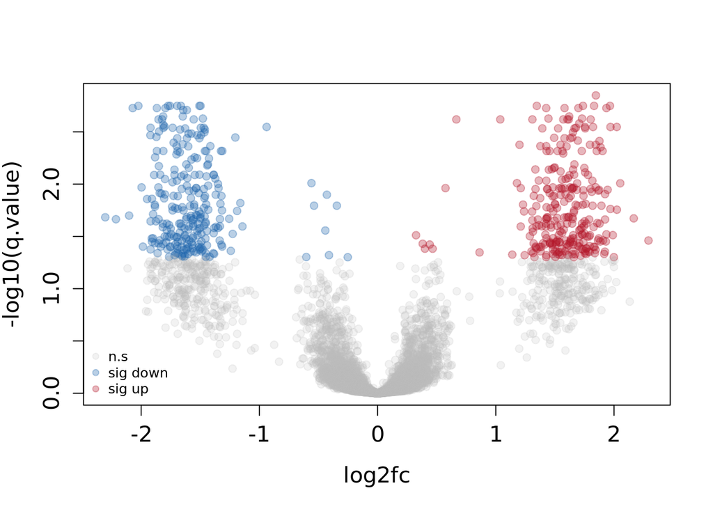

```r
AD = myVolcanoPlot(Experiment_DEG, 2:5, 6:9, 0.05)
```

```r
head(AD)
##   gene_id      Rep1      Rep2      Rep3      Rep4      Rep5      Rep6      Rep7
## 1  gene_1 105.39212  94.43991 116.86898 141.04485  93.34523 115.71146 113.25906
## 2  gene_2  87.40029 142.94498  51.73186  94.68184  70.89883 115.54474 102.72603
## 3  gene_3 117.37320  79.42240 121.76722  79.98960 108.93147 112.08996  76.63101
## 4  gene_4 134.54391  77.28999 126.44761  91.36372  78.83684 104.22875 105.84413
## 5  gene_5 100.48375 143.68578 105.27493 104.19477 116.44813  86.16445 107.04300
## 6  gene_6 107.36050 118.16668 108.50700  84.17187 109.03643 103.13020 111.16444
##        Rep8     pvals   p.value   mean.g1   mean.g2      log2fc   q.value
## 1  82.68450 0.3433882 0.3433882 114.43647 101.25006 -0.17662403 0.8684577
## 2 104.11582 0.8531525 0.8531525  94.18974  98.32135  0.06193481 0.9821852
## 3  87.15789 0.8196634 0.8196634  99.63810  96.20258 -0.05062193 0.9810751
## 4 115.79650 0.7106500 0.7106500 107.41131 101.17655 -0.08627089 0.9667933
## 5 110.42031 0.5177720 0.5177720 113.40981 105.01897 -0.11089547 0.9335481
## 6  69.55446 0.6208984 0.6208984 104.55151  98.22138 -0.09010490 0.9570114
```

# Install packages

If you cannnot find a function for what you are looking for, odds are, that somebody else already encountered the same problem and wrote a package for it. There are two main resources for additional packages in R. The more general packages can be found on [Cran](https://cran.r-project.org/). Packages related to analysis of biological data are most often found on [Bioconductor](https://www.bioconductor.org/). First find a package you are looking for via Google and read through the [manual](https://www.bioconductor.org/packages/release/bioc/vignettes/edgeR/inst/doc/edgeRUsersGuide.pdf) or the vingette to confirm that it is the right package for you. Ask yourself the following questions:

1. Is it applicable to my data?
2. Is it returning results I am interested in?
3. Is it being maintained?
4. Do I find the manual somewhat easy to understand?

### Cran

```r
# install the package, only need to do this once
install.packages('pheatmap')

# every time you start R and want to use the package, you need to load it
library(pheatmap)
```

### Bioconductor

```r
if (!requireNamespace("BiocManager", quietly = TRUE))
    install.packages("BiocManager", repos='http://cran.us.r-project.org' , dependencies = TRUE)

BiocManager::install("edgeR")

library(edgeR)
```

We will install more packages later. In general it is quite straight forward.

# Basic plotting functions

With R you can make various different plots and graphics. In this Workshop we will only cover basic plotting functions but we are more than happy to help you with a specific plot you are interested in.

## Scatter plot

Simple scatter plot. A scatterplot can be used to view how one variable (y) behaves with respect to another variable (x).

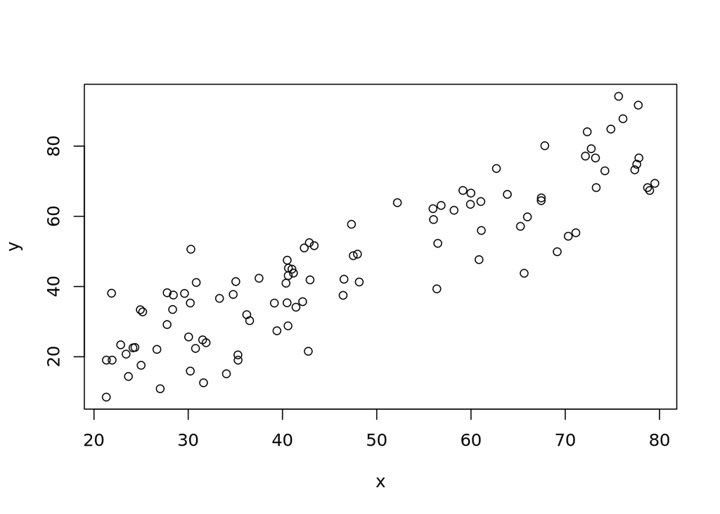

```r
# create two vectors with random variables
# 100 random numbers from a uniform distribution between 20 and 80
x = runif(100, 20, 80)
# 100 random numbers from a normal distribution but the mean is differen
# for every random number (depends on x)
y = rnorm(100, x, 10)

# plot
plot(x, y )
```

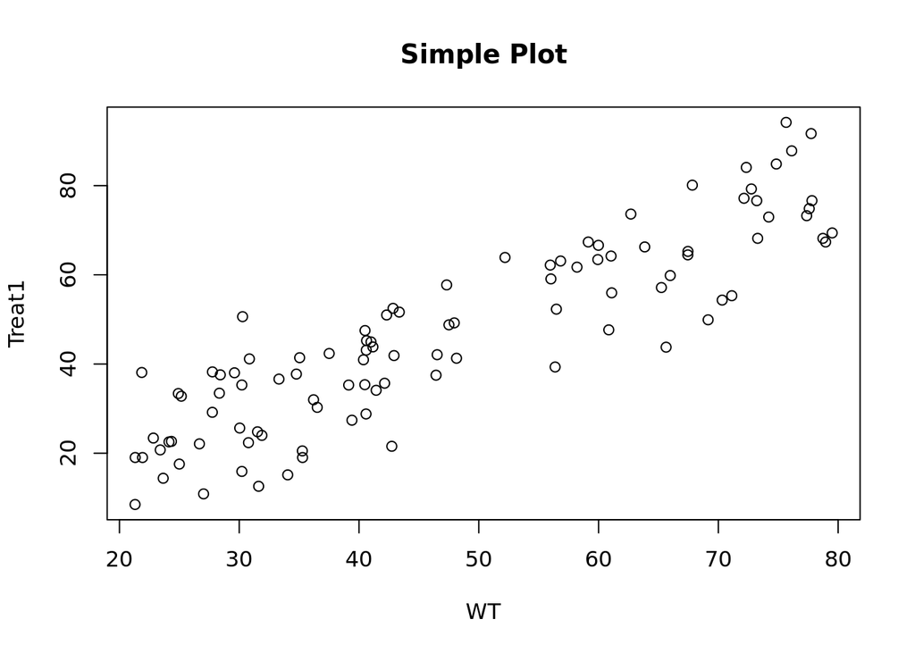

```r
# make the plot a bit prettier
# add title and axis labels
plot(x, y, main = 'Simple Plot', xlab = 'WT', ylab = 'Treat1')
```

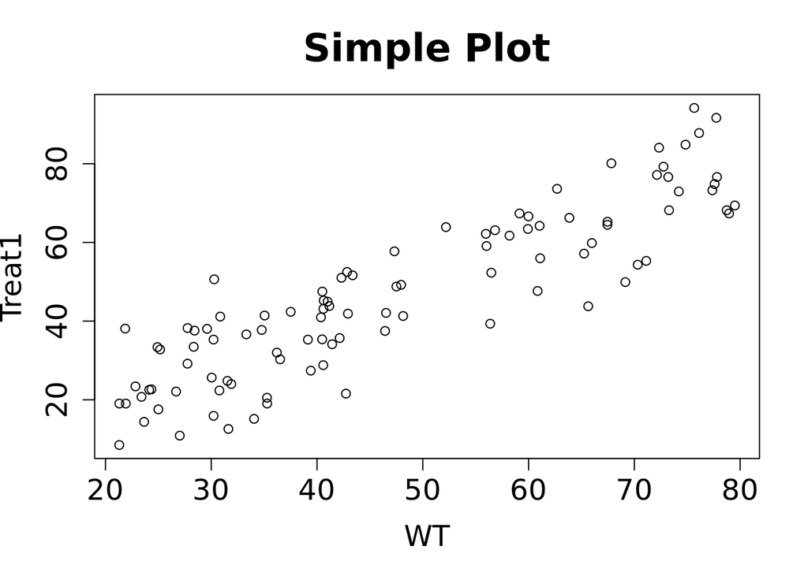

```r
# make the text bigger
plot(x, y, main = 'Simple Plot', xlab = 'WT', ylab = 'Treat1',
     cex.main = 2, cex.axis = 1.5, cex.lab = 1.5)
```

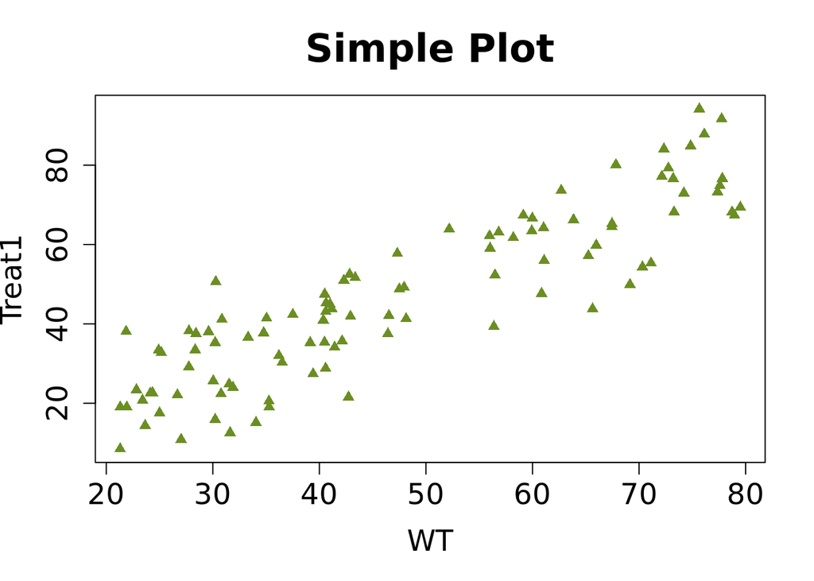

```r
# change the color and shape of the dots
plot(x, y, main = 'Simple Plot', xlab = 'WT', ylab = 'Treat1',
     cex.main = 2, cex.axis = 1.5, cex.lab = 1.5,
     pch = 17, col = 'olivedrab')
```

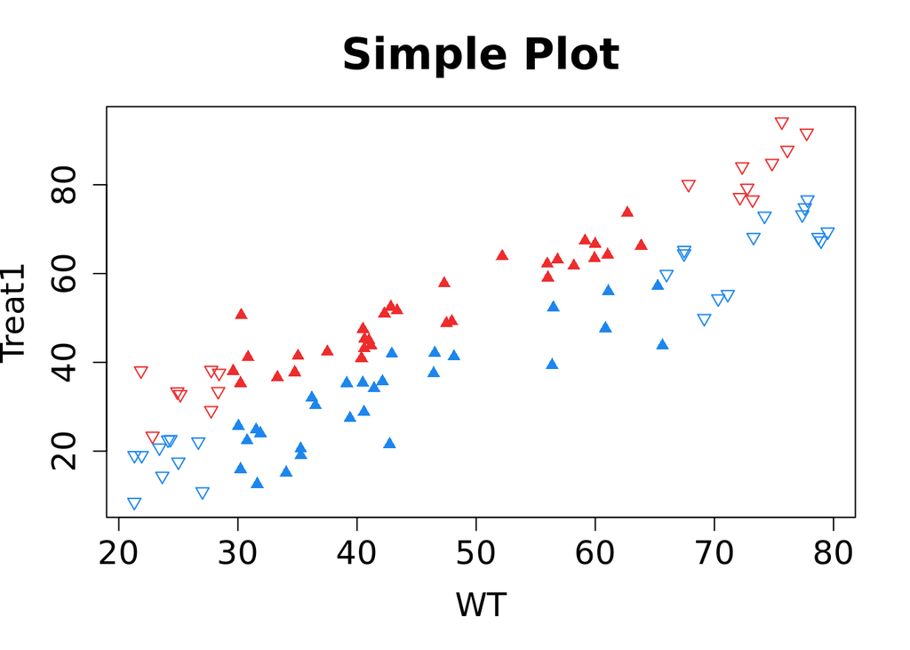

```r
# plot with shape and colors
plot(x, y, main = 'Simple Plot', xlab = 'WT', ylab = 'Treat1',
     cex.main = 2, cex.axis = 1.5, cex.lab = 1.5,
     pch = ifelse(abs(x - mean(x)) > sd(x), 6, 17),
     col = ifelse(y > x, 'firebrick2', 'dodgerblue2'))
```

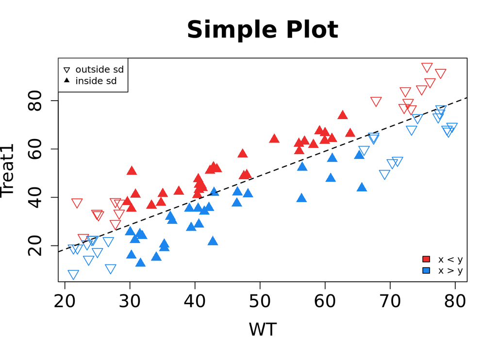

```r
# add a legends to the plot
plot(x, y, main = 'Simple Plot', xlab = 'WT', ylab = 'Treat1',
     cex.main = 2, cex.axis = 1.5, cex.lab = 1.5, cex = 1.5,
          pch = ifelse(abs(x - mean(x)) > sd(x), 6, 17),
     col = ifelse(y > x, 'firebrick2', 'dodgerblue2'))

legend('topleft', c('outside sd', 'inside sd'), pch = c(6, 17), cex = 0.8)
legend('bottomright', c('x < y', 'x > y'), fill = c('firebrick2', 'dodgerblue2'),
       cex = 0.8, bty = 'n')

# add a regression line
abline(lm(y ~ x), lty = 2, lwd = 1.5)
```

Resources to help you choose colors for your plot:  
- R color brewer: https://colorbrewer2.org/  
- R color pdf: http://www.stat.columbia.edu/~tzheng/files/Rcolor.pdf

### Hands On

- Read in your test data frame from the file `airway_gene_expression.tsv` and `airway_sample_info.tsv`.
  - `D = read.delim2(file, as.is = T, header = T)`
- Plot the mean over all samples before the intervention against the mean of all samples after the intervention with a nice title and axis labels.
  - select columns based on vector `airway.D[airway.I[airway.I$Intervention == "before",]$SampleName]`
  - calculate row wise mean (`rowMeans()`)
  - plot data (`plot(x = mean_before, y = mean_after, ...)`)
- Change the shape and color of the data points.
  - `plot(..., pch = ,...)` to change shape
  - `plot(..., col = ,...)` to change color
- Change the axis to log scale.
  - `plot(..., log = 'xy', ...)`

```
## [1] "head(airway.D)"
##            GeneID S_01.control.Rep1 S_02.__treat.Rep1 S_03.control.Rep2
## 1 ENSG00000000003               679               448               873
## 2 ENSG00000000005                 0                 0                 0
## 3 ENSG00000000419               467               515               621
## 4 ENSG00000000457               260               211               263
## 5 ENSG00000000460                60                55                40
## 6 ENSG00000000938                 0                 0                 2
##   S_04.__treat.Rep2 S_05.control.Rep3 S_06.__treat.Rep3 S_07.control.Rep4
## 1               408              1138              1047               770
## 2                 0                 0                 0                 0
## 3               365               587               799               417
## 4               164               245               331               233
## 5                35                78                63                76
## 6                 0                 1                 0                 0
##   S_08.__treat.Rep4
## 1               572
## 2                 0
## 3               508
## 4               229
## 5                60
## 6                 0
## [1] "head(airway.I)"
##          SampleName  Patient Intervention Sex Age
## 1 S_01.control.Rep1 Patient1       before   f  25
## 2 S_02.__treat.Rep1 Patient1        after   f  25
## 3 S_03.control.Rep2 Patient2       before   f  33
## 4 S_04.__treat.Rep2 Patient2        after   f  33
## 5 S_05.control.Rep3 Patient3       before   m  28
## 6 S_06.__treat.Rep3 Patient3        after   m  28
```

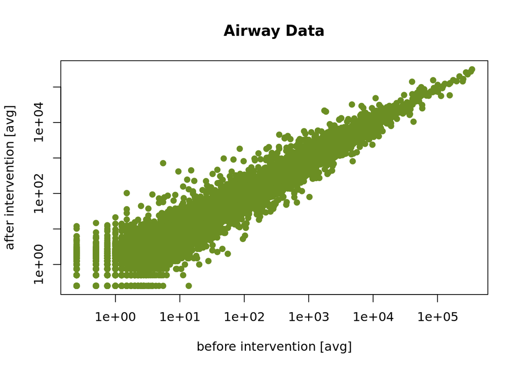

## Volcano plot

A volcano plot is a special type of scatter plot with the log2fc on the x-axis and the p-value on the y-axis. Usually, the significant dots are colored in red and the not significant dots in gray. In our field of research, these dots usually represent genes, proteins or metabolites. The fold change is calculate between two different groups (Condition, age, strain, etc.). The p.value is usually calculated a statistical test (t.test, wilcox.test).

```r
head(Experiment_DEG)
##   gene_id      Rep1      Rep2      Rep3      Rep4      Rep5      Rep6      Rep7
## 1  gene_1 105.39212  94.43991 116.86898 141.04485  93.34523 115.71146 113.25906
## 2  gene_2  87.40029 142.94498  51.73186  94.68184  70.89883 115.54474 102.72603
## 3  gene_3 117.37320  79.42240 121.76722  79.98960 108.93147 112.08996  76.63101
## 4  gene_4 134.54391  77.28999 126.44761  91.36372  78.83684 104.22875 105.84413
## 5  gene_5 100.48375 143.68578 105.27493 104.19477 116.44813  86.16445 107.04300
## 6  gene_6 107.36050 118.16668 108.50700  84.17187 109.03643 103.13020 111.16444
##        Rep8     pvals
## 1  82.68450 0.3433882
## 2 104.11582 0.8531525
## 3  87.15789 0.8196634
## 4 115.79650 0.7106500
## 5 110.42031 0.5177720
## 6  69.55446 0.6208984
```

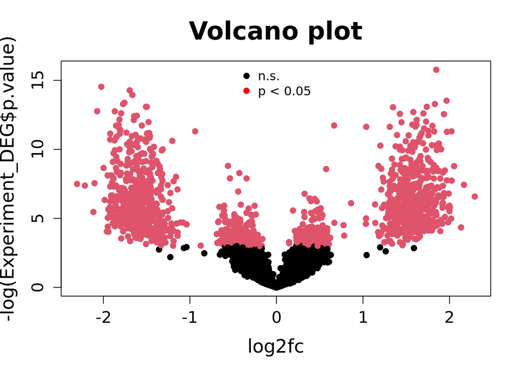

```r
# calculate p.values using t.test and apply
for(i in 1:nrow(Experiment_DEG)){
  # calculate p.value
  Experiment_DEG[i,'p.value'] = as.numeric(t.test(Experiment_DEG[i,2:5], Experiment_DEG[i,6:9])$p.value)
}

# to calculate the log2fc you first need to calculate the genewise mean of both groups
mean_groupA = rowMeans(Experiment_DEG[,2:5])
mean_groupB = rowMeans(Experiment_DEG[,6:9])

# calculate the log2fc based on the group means
log2fc = log2(mean_groupB/mean_groupA)

# plot the data
plot(x = log2fc, y = -log(Experiment_DEG$p.value), col = as.factor(Experiment_DEG$p.value < 0.05),
     main = 'Volcano plot', pch = 19, cex.axis = 1.3, cex.lab = 1.5, cex.main = 2)
legend('top', c('n.s.', 'p < 0.05'), col = c('black', 'red'), pch = 19, bty = 'n')
```

Not exactly how most volcano plots look like, but this nicely represents how the synthetic data was generated.

### Hands On

Work on the airway dataset

```r
airway.ge = read.delim("data/airway_gene_expression.tsv", as.is = T, header = T, sep = '\t')
# make Gene ID to row names
head(airway.ge, n = 5)
##            GeneID S_01.control.Rep1 S_02.__treat.Rep1 S_03.control.Rep2
## 1 ENSG00000000003               679               448               873
## 2 ENSG00000000005                 0                 0                 0
## 3 ENSG00000000419               467               515               621
## 4 ENSG00000000457               260               211               263
## 5 ENSG00000000460                60                55                40
##   S_04.__treat.Rep2 S_05.control.Rep3 S_06.__treat.Rep3 S_07.control.Rep4
## 1               408              1138              1047               770
## 2                 0                 0                 0                 0
## 3               365               587               799               417
## 4               164               245               331               233
## 5                35                78                63                76
##   S_08.__treat.Rep4
## 1               572
## 2                 0
## 3               508
## 4               229
## 5                60
```

- Remove low abundant `rowMeans < 5` genes from the airway data
  - calculate the `RM = rowMeans()` using columns `2:9` of `airway.ge`
  - subset `airway.ge` using `subset(airway.ge, RM > 5)`
- Calculate a p-value for your test data frame
  - use a `for(i in 1:nrow(expressed.airway)){ calculate p-value for row i}`
  - calculate p.value using t.test `as.numieric(t.test()$p.value)`
- Calculate the log2 fold changes using average across the replicates
  - calculate `mean.before = rowMean(expressed.airway[, <correct columns>])`
  - calculate `mean.after = rowMean(expressed.airway[, <correct columns>])`
  - `log2(mean.after/mean.before)`
- Plot a volcano plot
  - `plot(x = log2fc, y = -log10(p.value), ...)`
- Add a line at p = 0.01
  - add horizontal lines using `abline(h = )`
- Add a legend
  - add legend using `legend()`

```
## [1] "log2fc"
##           1           3           4           5           7           8
## -0.48334351  0.06407037 -0.09840370 -0.25397507  0.33790012 -0.40561046
## [1] "pvalue"
##          1          3          4          5          7          8
## 0.22082663 0.82755428 0.67474685 0.38412456 0.49498597 0.04771523
```

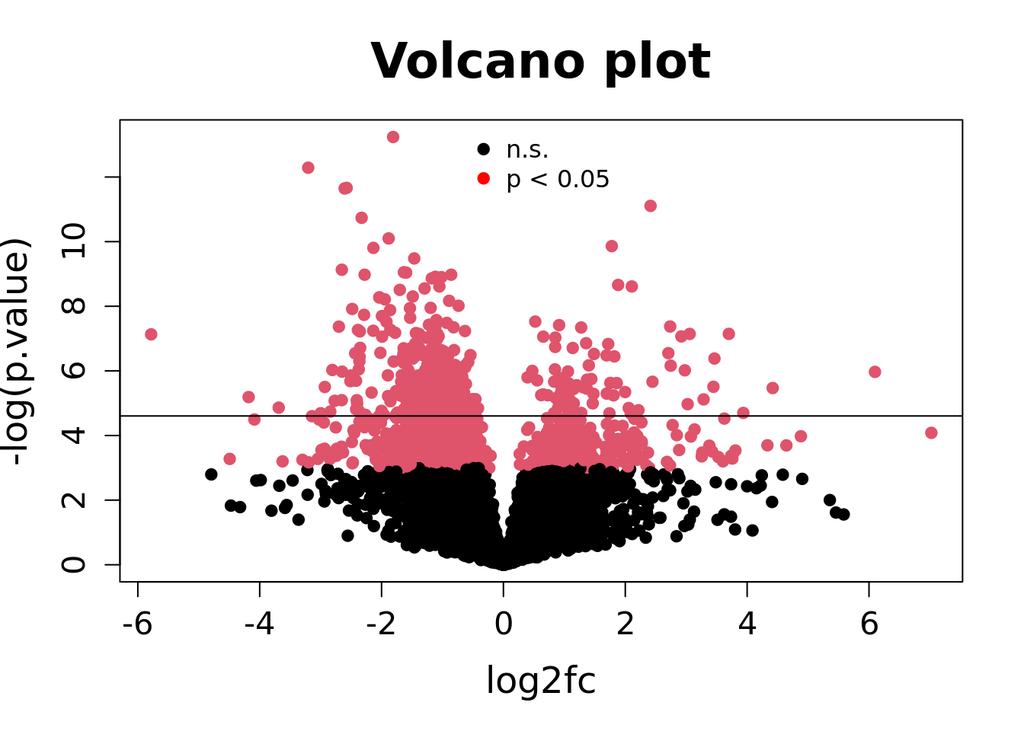

## PCA plot

- The principal component analysis (pca) is an orthogonal transformation
- Correlated variables → linearly uncorrelated variables (principal components, PC)
- Dimensionality reduction, # PC <= min(# observation, # variables)
- First PC has the largest possible variance
- Different algorithms to obtain PCs
- PCA is mostly used as a tool in:
  - exploratory data analysis
  - visualize genetic distance and relatedness between populations.

```r
# load example data
wine = read.csv('data/wine.csv')
head(wine)
```

```
##   Cvs Alcohol Malic.acid  Ash Alcalinity.of.ash Magnesium Total.phenols
## 1   1   14.23       1.71 2.43              15.6       127          2.80
## 2   1   13.20       1.78 2.14              11.2       100          2.65
## 3   1   13.16       2.36 2.67              18.6       101          2.80
## 4   1   14.37       1.95 2.50              16.8       113          3.85
## 5   1   13.24       2.59 2.87              21.0       118          2.80
## 6   1   14.20       1.76 2.45              15.2       112          3.27
##   Flavanoids Nonflavanoid.phenols Proanthocyanins Color.intensity  Hue
## 1       3.06                 0.28            2.29            5.64 1.04
## 2       2.76                 0.26            1.28            4.38 1.05
## 3       3.24                 0.30            2.81            5.68 1.03
## 4       3.49                 0.24            2.18            7.80 0.86
## 5       2.69                 0.39            1.82            4.32 1.04
## 6       3.39                 0.34            1.97            6.75 1.05
##   OD280.OD315.of.diluted.wines Proline
## 1                         3.92    1065
## 2                         3.40    1050
## 3                         3.17    1185
## 4                         3.45    1480
## 5                         2.93     735
## 6                         2.85    1450
```

```r
# define the first column as a factor
wineClasses = factor(wine$Cvs)
# compute principal component
winePCA = prcomp(scale(wine[, -1]))
# look at the results
summary(winePCA)
```

```
## Importance of components:
##                          PC1    PC2    PC3     PC4     PC5     PC6     PC7
## Standard deviation     2.169 1.5802 1.2025 0.95863 0.92370 0.80103 0.74231
## Proportion of Variance 0.362 0.1921 0.1112 0.07069 0.06563 0.04936 0.04239
## Cumulative Proportion  0.362 0.5541 0.6653 0.73599 0.80162 0.85098 0.89337
##                            PC8     PC9   PC10    PC11    PC12    PC13
## Standard deviation     0.59034 0.53748 0.5009 0.47517 0.41082 0.32152
## Proportion of Variance 0.02681 0.02222 0.0193 0.01737 0.01298 0.00795
## Cumulative Proportion  0.92018 0.94240 0.9617 0.97907 0.99205 1.00000
```

```r
# look at the names of the results in order to find out what you can use to plot
names(winePCA)
```

```
## [1] "sdev"     "rotation" "center"   "scale"    "x"
```

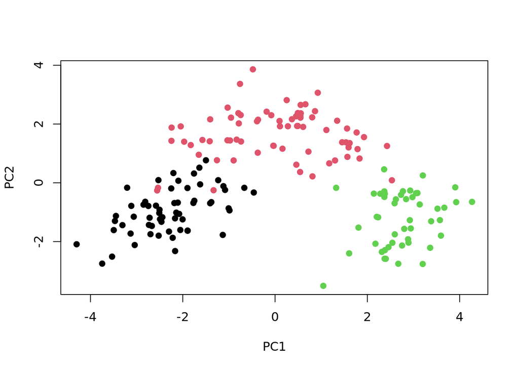

```r
# plot first vs. second component as scatterplot
plot(winePCA$x[,1:2], col = wineClasses, pch = 19)
```

### Hands On

- Perform a PCA on the your test data (for the samples)
  - calculate pca only on numeric data `prcomp(t(airway.ge[,<correct columns>]))`
- Plot the data using the coordinate system of the first and second component
  - plot data in new coordinate system: `plot(pca$x[, <correct column for first and second component>], ...)`
- Color dots based on before and after intervention
  - `plot(..., col = , ...)`
- Give each patient a different shape
  - `plot(..., pch = , ...)`
- Add a legend
  - `legend()`

```
## Importance of components:
##                            PC1     PC2      PC3      PC4      PC5      PC6
## Standard deviation     96.8163 55.4581 40.56263 36.99393 33.00294 26.81905
## Proportion of Variance  0.5267  0.1728  0.09246  0.07691  0.06121  0.04042
## Cumulative Proportion   0.5267  0.6996  0.79204  0.86895  0.93015  0.97057
##                             PC7       PC8
## Standard deviation     22.88373 1.223e-14
## Proportion of Variance  0.02943 0.000e+00
## Cumulative Proportion   1.00000 1.000e+00
```

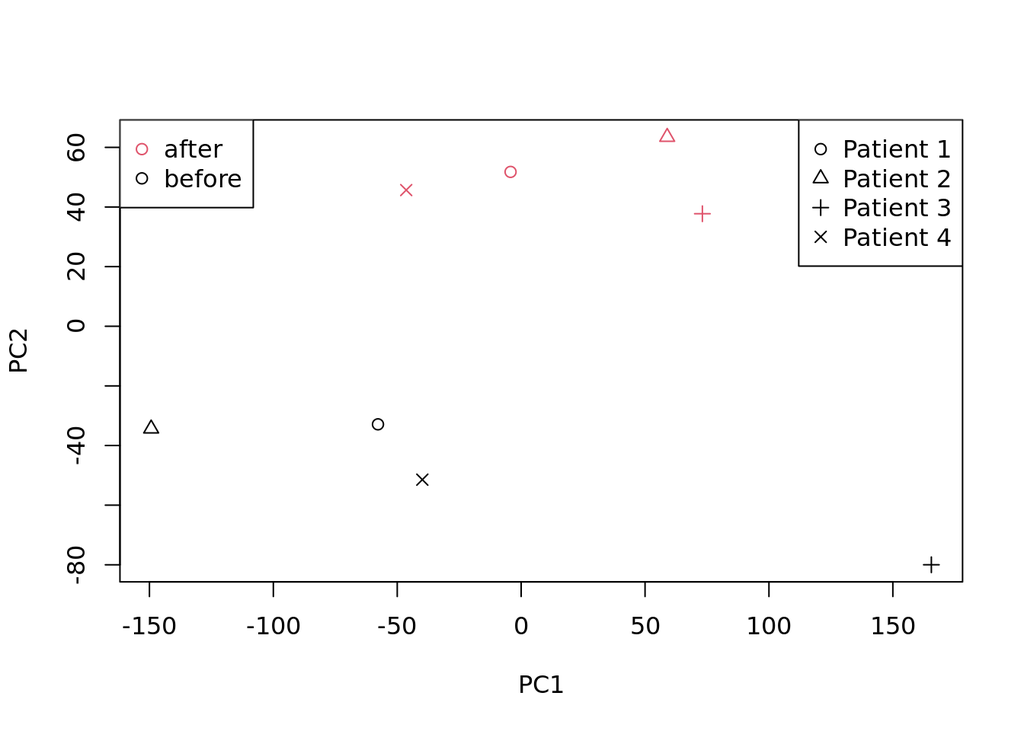

## Other plot option

Using the `type` argument in the `plot(x, y, ..., type = ...)` function allows you to change the style how the data is portrayed. This table gives an overview of the different options

| symbol | plot |
| --- | --- |
| “p” | for points (default) |
| “l” | for lines |
| “b” | for lines between the dots, but dots as points |
| “c” | for the lines part alone of “b” |
| “o” | for lines and dots to be ‘overplotted’ |
| “h” | for ‘histogram’ like vertical lines |
| “s” | for stair steps |
| “S” | for other steps, see ‘Details’ |
| “n” | for no plotting |

Example

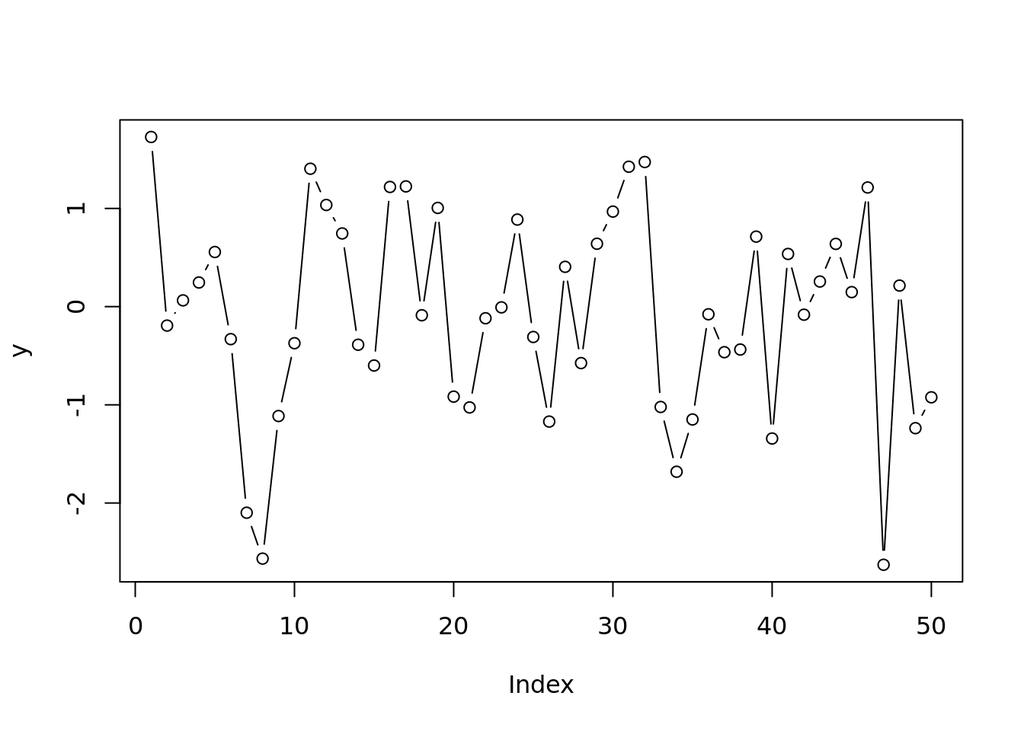

```r
y = rnorm(50)
plot(y, type = 'b')
```

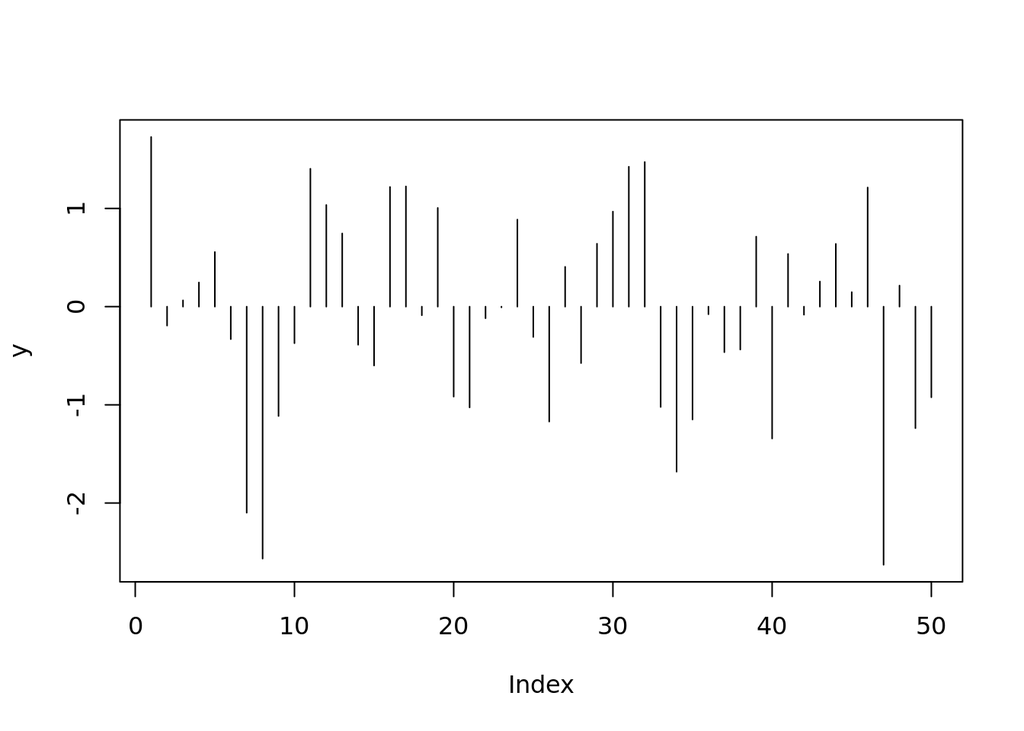

```r
plot(y, type = 'h')
```

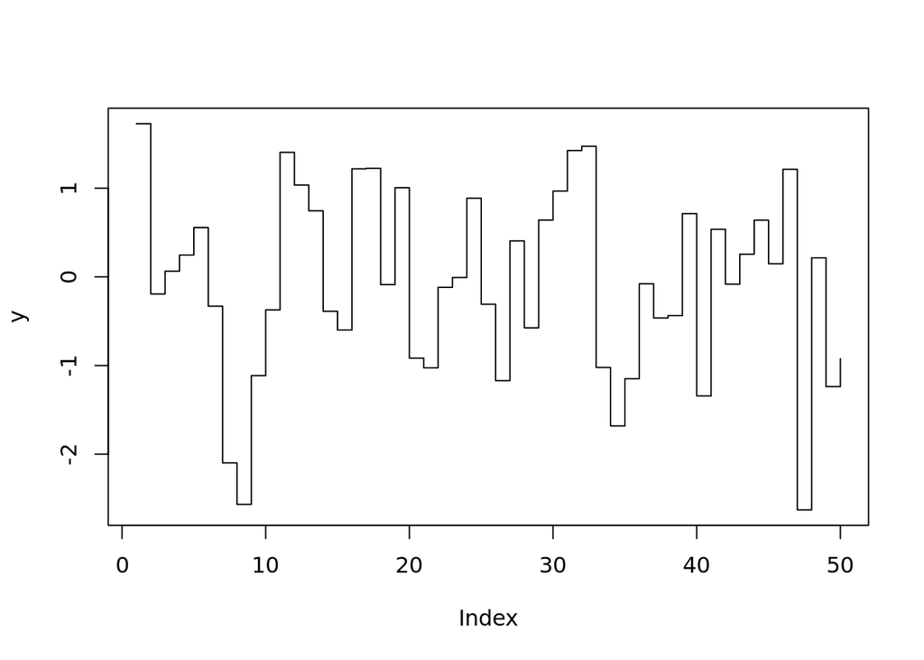

```r
plot(y, type = 's')
```